# Final Project: An Analysis of 1,000 posts from the subreddit "AITA" (Am I the asshole)

*Robert Huarcaya* Moustafa Farag

We will describe how to analyze the data. The fisrt step is to get some data. We will use data from https://github.com/Andrew-Sai/reddit-aita/tree/master/data You can also find some code that we won't use since it is hard to understant. So, just go to internet and find a good data! Below are some links where you can find some data:

https://www.kaggle.com/datasets (All kind of data from anime to econoimics)

https://opendata.maryland.gov/ (Data from the state of Maryland. In fact, most states have a similar website)

https://www.bea.gov/ (Why to limit to a state when you can look at the whole country? This website provides infomration from the U.S.A.)

After you find some data in which you are interested. Please make sure it is meaningful to look at the data of youe election. Below is our motivation for working with the data from Reddit to analyze social media behavior.

# Motivation

On Reddit, you can publish controversial stories and let other users to judge in you were on fault, the other person was on fault, everyone was on fault, or nobody was on fault. To be precise Reddit uses 4 categories: Asshole, Not An Asshole, Everyone sucks, NO A-holes here.

We will be analyzing the subreddit AITA using 1,000 posts to see if we can predict behavior from Reddit users and also to understand the relation between the final verdict and the number of likes and commments that post gets. The ultimate goal is to determine how a user can maximize the number of likes and comments.

# 1. Getting the Data into Python

After you download the data you are working on, you have to get it into Python in a table. Fortunately, Pandas has a wide variety of functions to work with different types of files. In this case, we use a function to read csv files. There are more functions to read Excel files, SAS files, and so on.

Note: Include the import statements for the libraries you are using. The ones we are using in this tutorial are the most basic libraries that you should not hesitate in using.

```python
import pandas as pd
import numpy as np
import matplotlib.pyplot as plt
import seaborn as sns

names=['title', 'author', 'likes', 'comments', 'story', 'timestamp', 'verdict']

# We are adding more names to the array like user_comment1, user_comment2, ...
for i in range(1, 11):
    comment_number = "user_comment{}".format(i)
    names.append(comment_number)
df = pd.read_csv('reddit_aita.csv', names=names)
```

# Remember...

To keep track of the meaning of all your variables. Here it is a description for the columns in our table.

'title': The title of the post  
'author': The username of the person making the post 'likes': Number of likes on the post 'comments': Number of comments on the post  
'story': The body of the post 'timestamp': Date in which it was posted on Reddit  
'verdict': The final verdict given by the Redditors reading the story  
'user_commentI': The comments of a redditor on position I. We included only the first 10 commments of each post.

# Looking at data

Verify that the number of non-null values, the type of the columns + names are as expected

```python
df.info(verbose=True)
```

```
<class 'pandas.core.frame.DataFrame'>
RangeIndex: 946 entries, 0 to 945
Data columns (total 17 columns):
 #   Column          Non-Null Count  Dtype
---  ------          --------------  -----
 0   title           946 non-null    object
 1   author          946 non-null    object
 2   likes           946 non-null    object
 3   comments        946 non-null    int64
 4   story           946 non-null    object
 5   timestamp       946 non-null    object
 6   verdict         946 non-null    object
 7   user_comment1   946 non-null    object
 8   user_comment2   946 non-null    object
 9   user_comment3   944 non-null    object
 10  user_comment4   944 non-null    object
 11  user_comment5   944 non-null    object
 12  user_comment6   944 non-null    object
 13  user_comment7   944 non-null    object
 14  user_comment8   944 non-null    object
 15  user_comment9   943 non-null    object
 16  user_comment10  943 non-null    object
dtypes: int64(1), object(16)
memory usage: 125.8+ KB
```

# CLEANING DATA

When you get your data is almost gurranted that you will have to clean it. By cleaning your data, we meant to foramt your data in such a way that is usable. Below, you will get a clear idead what we meant...

Before continuing, if you have not worked with data frames in R, SAS, or another programming language, we recommend you to read the tutorial on https://www.w3schools.com/python/pandas/default.asp

Now, it is time to sweep our data.

```python
print(df["likes"].value_counts())
```

```
17.6k    9
14.9k    7
13.1k    7
13.5k    6
11.1k    6
        ..
7988     1
7984     1
8009     1
8012     1
3898     1
Name: likes, Length: 640, dtype: int64
```

Definition to get rid of the k's at the end

```python
def with_outk(my_str):
    if my_str == None:
        return None
    elif my_str[len(my_str)-1] == "k": #getting rid of the k.
        return str(float(my_str[0:len(my_str)-1])*100)
    else:
        return my_str
```

Applying the function to the column "likes"

```python
df["likes"] = df["likes"].apply(lambda x : with_outk(x))
```

Now we should be able to change the type of the column "likes"

```python
df["likes"] = pd.to_numeric(df["likes"])
```

```python
#Verifying the change of type worked
df.info()
```

```
<class 'pandas.core.frame.DataFrame'>
RangeIndex: 946 entries, 0 to 945
Data columns (total 17 columns):
 #   Column          Non-Null Count  Dtype
---  ------          --------------  -----
 0   title           946 non-null    object
 1   author          946 non-null    object
 2   likes           946 non-null    float64
 3   comments        946 non-null    int64
 4   story           946 non-null    object
 5   timestamp       946 non-null    object
 6   verdict         946 non-null    object
 7   user_comment1   946 non-null    object
 8   user_comment2   946 non-null    object
 9   user_comment3   944 non-null    object
 10  user_comment4   944 non-null    object
 11  user_comment5   944 non-null    object
 12  user_comment6   944 non-null    object
 13  user_comment7   944 non-null    object
 14  user_comment8   944 non-null    object
 15  user_comment9   943 non-null    object
 16  user_comment10  943 non-null    object
dtypes: float64(1), int64(1), object(15)
memory usage: 125.8+ KB
```

Now we proceed to clean the verdict column. There are too many strings representing the same category as we see below; for instance, UPDATE and Update clearly are the same category

```python
print(df["verdict"].value_counts())
```

```
Not the A-hole            597
Asshole                   178
No A-holes here            59
Everyone Sucks             47
Update                     16
META                       14
UPDATE                      9
No-Flair                    9
Not enough info             3
not the a-hole              2
Probably Fake               2
everyone sucks              1
Fake Story                  1
Shitpost                    1
Not the A-hole (oof)        1
Record Setting Asshole      1
Actually Meta               1
probably fake               1
weeabo h8r                  1
META Asshole                1
Update                      1
Name: verdict, dtype: int64
```

```python
#First we union all the A-hole verdicts
df["verdict"]= df["verdict"].replace(["META","Record Setting Asshole", "Actually Meta", "META Asshole" ], "Asshole")

#Second the not A-holes are unified
df["verdict"]= df["verdict"].replace(["Not the A-hole", "not the a-hole", "Not the A-hole (oof)"  ], "Not Asshole")

#third, joining fake stories
df["verdict"]= df["verdict"].replace(["Probably Fake", "probably fake", "Fake Story", "Shitpost" ], "Fake")

#Joining update stories
df["verdict"]= df["verdict"].replace(["Update", "UPDATE", "Update" ], "Update")

#joinig veredicts in which everyone was guilty
df["verdict"]= df["verdict"].replace(["Everyone Sucks", "everyone sucks" ], "Everyone Sucks")
```

# WE START REMOVING SOME ROWS...

Out of the almost 1,000 stories in our dataset, only 5 are believed to be fake stories. Thankfully, the subreddit is already filtered by the moderators so the minimal missing data is negligable

```python
index = df[ df['verdict'] == "Fake" ].index
df.drop(index , inplace=True)
```

The next step in cleaning our data is to remove missing data. This includes unhelpful verdicts like "weeabo h8r", "Not enough info", and "no flair". We will also ignore posts marked as "META" because those posts are discussions about the state of the subreddit and do not contain any stories to be judged We tried the code below but the boolean expression was hard to understand. so we extended it in separate steps. df.drop(df[ (df['verdict'] == "No-Flair") or (df['verdict'] == "weeabo h8r")].index, inplace=True)

```python
index = df[ df['verdict'] == "No-Flair" ].index #getting the indexes of the rows to drop
df.drop(index , inplace=True) #dropping the collumns. Notice we use inplace = True. This means the changes are made in the df

index = df[ df['verdict'] == "weeabo h8r" ].index
df.drop(index , inplace=True)


index = df[ df['verdict'] == "Not enough info" ].index
df.drop(index , inplace=True)

index = df[ df['verdict'] == "META" ].index
df.drop(index , inplace=True)

index = df[ df['verdict'] == "Actually Meta" ].index
df.drop(index , inplace=True)
```

We noticed a small problem with the "update" verdict that allowed a white space character to get in the way

```python
print(df["verdict"].unique())
```

```
['Update' 'Asshole' 'Everyone Sucks' 'No A-holes here' 'Not Asshole'
 'Update ']
```

So, we decided to drop the white space characters and combine all the different versions of "update ..." together

```python
df["verdict"]= df["verdict"].replace(["Update "], "Update")
```

We notice that we do not need the update for our analysis, since we are trying to investigate how the verdict relates to the other variables in our data frame. The "update" veridct defets the purpose becasue we do not know the original verdict of the publication. So we will drop those rows as well.

```python
index = df[ df['verdict'] == "Update" ].index
df.drop(index , inplace=True)
```

At this point we have only two numerical values. We will look at their basic statistics

```python
df.describe()
```

|  | likes | comments |
| --- | --- | --- |
| count | 902.000000 | 902.000000 |
| mean | 3976.962306 | 1776.467849 |
| std | 2512.193197 | 1360.502419 |
| min | 1000.000000 | 18.000000 |
| 25% | 1670.000000 | 839.500000 |
| 50% | 3905.000000 | 1347.000000 |
| 75% | 5829.250000 | 2260.500000 |
| max | 9983.000000 | 10639.000000 |

Now that we get our basic statistics, we can get an idea of how the data could look. However, we remark that the mean and standard deviation are very sensible to outliers. It is very useful to use the median and the interquartile range. In case you do not know the difference between mean and median, we suggest you to read https://www.diffen.com/difference/Mean_vs_Median

A extremely useful way to visualise the median and the interqurtile range is a boxplot. Remember people usually prefer pictures and movies.

```
[Text(0.5, 1.0, 'Boxplot for Likes')]
```

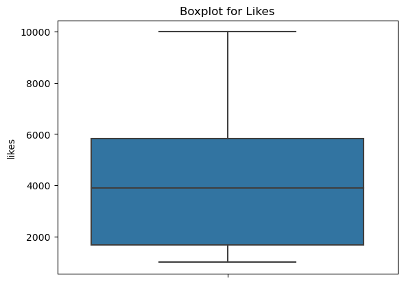

```python
sns.boxplot(y=df["likes"] ).set(title='Boxplot for Likes')
```

This boxplot shows that there are not outliers in the general for likes. The outliers appear beyond the two horizontal lines that are bounding the boxplot. If there are outliers, we should consider removing them. Since we are interested in the relationship between verdicts and the other varibles, we will make boxplots for each verdict.

```
[Text(0.5, 1.0, 'Boxplot for Likes per Verdict')]
```

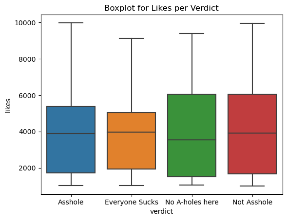

```python
sns.boxplot( x=df["verdict"], y=df["likes"] ).set(title='Boxplot for Likes per Verdict')
```

As we can see there are no outliers for any of the verdicts. Besides, we notice that the median for all verdict is around 4000. Now, we repeat the same process for the number of comments.

```
[Text(0.5, 1.0, 'Boxplot for Number of Comments')]
```

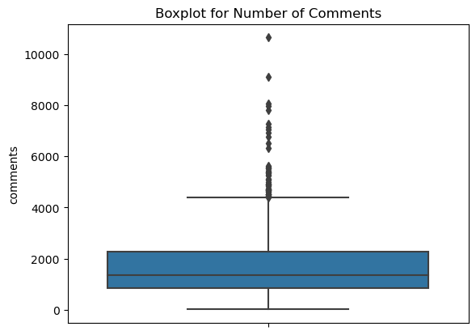

```python
sns.boxplot(y=df["comments"] ).set(title='Boxplot for Number of Comments')
```

```
[Text(0.5, 1.0, 'Boxplot for Number of Comments per Verdict')]
```

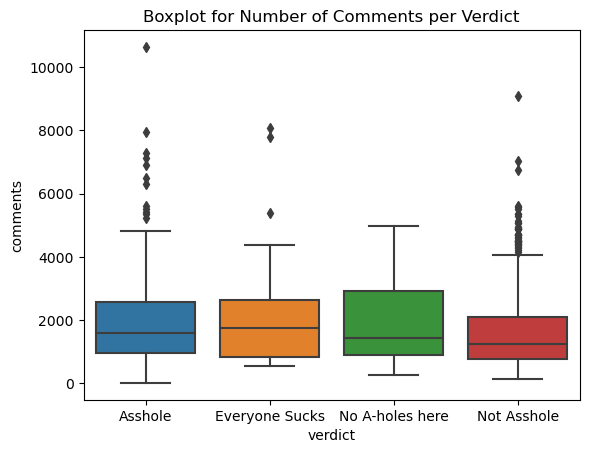

```python
sns.boxplot( x=df["verdict"], y=df["comments"] ).set(title='Boxplot for Number of Comments per Verdict')
```

As we can see from both boxplots for comments, there are outliers. Since these outliers only appear in one dimention (number of comments, but not likes), we will remove them. If they were truly outliers, they should be also outliers in the likes dimension. Thus, this outliers can be originated from other phenomena not related to the data itselg. For instance, it could be the case that there was a social wave for which people commented more during a period of time. This example suggest that you should consider in general seasonal patterns in your data. Unfortunately, we do not have time to cover this aspect of our data in this tutorial. If you are intersted in reading more about seasonality, we recommend you to read, https://machinelearningmastery.com/time-series-seasonality-with-python/

We continue with our approach. We will apply the elimination by interquartile that is described in the link below:

https://www.askpython.com/python/examples/detection-removal-outliers-in-python

```python
#Setting cooments to NaN for outliers
for x in ['comments']:
    q75,q25 = np.percentile(df.loc[:,x],[75,25])
    intr_qr = q75-q25

    max = q75+(1.5*intr_qr)
    min = q25-(1.5*intr_qr)

    df.loc[df[x] < min,x] = np.nan
    df.loc[df[x] > max,x] = np.nan

#Counting outliers
df["comments"].isnull().sum()
```

```
53
```

We have 53 outliers. It is time to remove them

```python
df.dropna(axis = 0, subset = ["comments"], inplace = True)
```

After removing outliers from our data, we will explore the distributions of our data. So, we will introduce a violin plot which shows this distrbution of the data as well as the mean, median, and the interquartile range. You can read more about it here:

https://seaborn.pydata.org/generated/seaborn.violinplot.html

Just so you know using histograms is another common technique to plot distributuons.

```
[Text(0.5, 1.0, 'Violin Plot For Likes')]
```

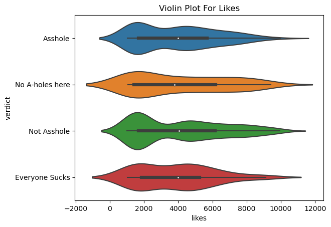

```python
sns.violinplot(data=df, x="likes", y="verdict").set(title='Violin Plot For Likes')
```

```
[Text(0.5, 1.0, 'Violin Plot For Number of Comments')]
```

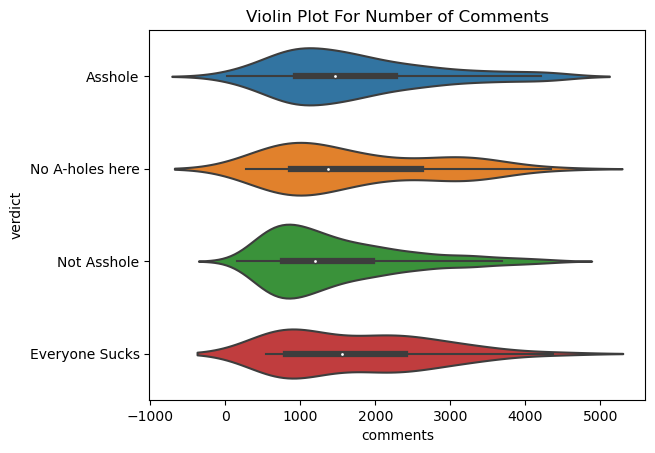

```python
sns.violinplot(data=df, x="comments", y="verdict").set(title='Violin Plot For Number of Comments')
```

# Exploration 0

We verify our unique values and we notice everything works fine. We want to know how many people are in each verdict. If people genuinely don't know if they were in the right or not, we should expect a randon uniform distribution. In other words, we should be expecting a perfect split between as-holes and non as-holes. Similarly, we should expect a perfect split for the verdicts "everyone sucks" and "no-assholes here".

```python
verdict = df["verdict"].value_counts()
```

We make a pie chart to got an idea of the number of people in each category

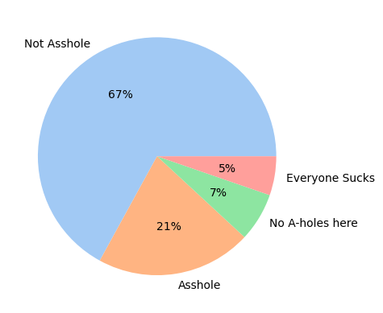

```python
colors = sns.color_palette('pastel')[0:5]

#define data
data = [569, 179, 56, 45]
labels = ['Not Asshole', 'Asshole', 'No A-holes here', 'Everyone Sucks']

#create pie chart
plt.pie(data, labels = labels, colors = colors, autopct='%.0f%%')
plt.show()
```

The subreddit AITA is a place where users can submit their personal stories to be judged by other reddit users for fault.

The original poster, or OP, of each story should be posting something controversial, with approximately a 50/50 split on who is the asshole of the story. It should be uniformly distributed. However, after looking at the skew of verdicts in our dataset, we can quickly see the abundance of "Not the asshole" verdicts, meaning that OP is not at fault. So, why is the dataset heavily skewed in that direction?

One possible answer is that most users on the subreddit already know the verdict before making their post and they are only seeking validation. Another less likely possibility is that people are biased in the way they tell stories, leading others to believe that they are innocent, even if they are not.

We also notice that the two verdicts "everyone sucks" and "no a-holes here" are equally likely, which leads us to the conclusion that when the story does not have a clear cut party at fault, the results actually indicate a lack of bias in the story. Since the results have heavily favored OP, we actually thought that "no a-holes here" would be a more likely verdict than "everyone sucks", since that would have also favored OP due to the tendency for seeking validation.

If the users were confused about the morality of their situation, we should expect a nice split for asshole and not an asshole like the red line shows below

```
[Text(0.5, 0, 'Total People'),
```

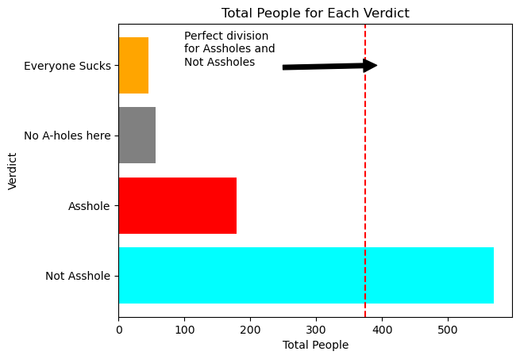

```python
fig, ax = plt.subplots()
colors = ['cyan', 'red', 'gray', 'orange']
ax.barh(verdict.index, verdict, color = colors)
# Add a vertical line, here we set the style in the function call

split = (verdict["Not Asshole"]+verdict["Asshole"])/2 #perfect split if they were perfectly random
ax.axvline(split, ls='--', color='r')

plt.annotate('Perfect division\nfor Assholes and\nNot Assholes', xy=(400, 3), xytext=(100, 3),
             arrowprops=dict(facecolor='black', shrink=0.05),
             )


ax.set( xlabel='Total People', ylabel='Verdict',
       title='Total People for Each Verdict')
```

# Exploration 1

Total likes V.S Verdicts We want to know if people like more the posts in wich there are assholes (those stories they may be considered more entertaining) or no.

```
[Text(0, 0.5, 'Total likes'),
```

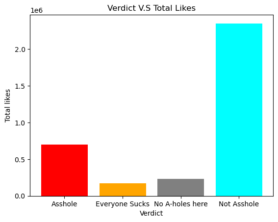

```python
totals_by_verdict = df.groupby(['verdict']).sum() #return data frame

fig, ax = plt.subplots()
colors = ['red', 'orange', 'gray', 'cyan']
ax.bar(totals_by_verdict.index, totals_by_verdict['likes'], color = colors)

ax.set( ylabel='Total likes', xlabel='Verdict',
       title='Verdict V.S Total Likes')



#totals_by_verdict["likes"].index
#totals_by_verdict["Update"]
```

We notice that the previous plot is not very informative because there are more posts with the verdict "Not Asshole", so unsurprisingly, those posts as a collective will have more total likes than posts with other verdicts.

Instead, looking at the avg likes per verdict gives us more accurate data

```
[Text(0.5, 0, 'Avg. Number of Likes'),
```

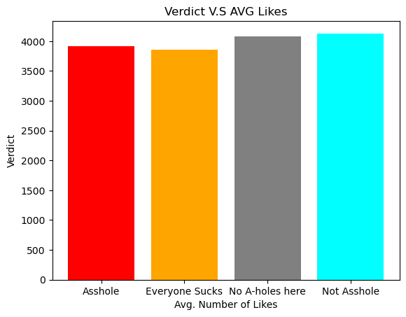

```python
totals_by_verdict = df.groupby(['verdict']).mean() #return data frame containing the means for each verdict

fig, ax = plt.subplots()
ax.bar(totals_by_verdict.index, totals_by_verdict["likes"], color = colors)

ax.set( xlabel='Avg. Number of Likes', ylabel='Verdict',
       title='Verdict V.S AVG Likes')
```

# EXPLANATION

This plot suggests that on average, people like the post at the same rate regardless of the verdict. Our assumption would have been that users are more likely to like a post that has a verdict "Not the asshole", because they agree with the story teller, this turned out to be false.

Someone who is familiar with the subreddit "AITA" will know that there are so many people making posts looking for validation that users are sick of them. So when there actually is a post where the OP is an asshole, people upvote it so it gains visibility on the subreddit, because these posts aren't boring like most. So the fact that people are giving likes to people they disagree with isn't some groundbreaking psychology discovery, it is due to context.

When analyzing data, we always have to think about context, otherwise our conclusions will be incorrect. Statistics aren't cut and dry.

Now we will explore a different visualisation of the data we will plot each of the number of likes each observationn got. This plot has as main purpose just to show you another way to visualize data. Indeed, the plot below does not contain more meaningful infomration than the previous plots.

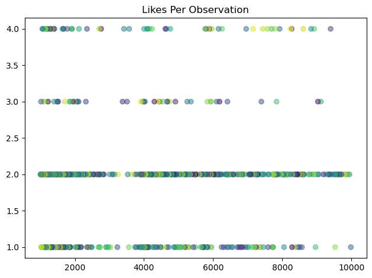

```python
plt.rcParams.update({'figure.autolayout': True})

fig, ax = plt.subplots()
verdict_ints = { 'Asshole' : 1, 'Everyone Sucks' : 3, 'No A-holes here': 4, 'Not Asshole':2 }
df["verdict_int"] = df["verdict"].apply(lambda x: verdict_ints[x]) #Assigning a verdict number to each row




ax.set(title='Likes Per Observation')

ax.scatter(df["likes"], df["verdict_int"], c=np.random.randint(0, 1000, 849),alpha=.5)
```

# Exploration 2:

Number of comments and number of likes. Here we will try to find if there is some kind of dependency between likes and total number of comments. In other words, we try to find if people comment more post that are liked or not. Our guess is that there is a linear relationship between likes and comments

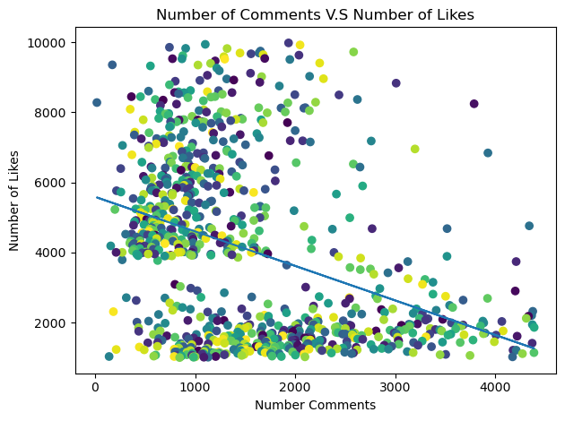

```python
plt.rcParams.update({'figure.autolayout': True})
fig, ax = plt.subplots()
ax.scatter(df["comments"], df["likes"], c=np.random.randint(0, 100, 849))
#adding linear regression
m, b = np.polyfit(df["comments"], df["likes"] , 1)
plt.plot(df["comments"], m*df["comments"]+b)

plt.xlabel('Number Comments')
plt.ylabel('Number of Likes')
plt.title("Number of Comments V.S Number of Likes")
```

If the number of likes outnumbers the number of comments then the hypothesis is that the verdict is not the asshole and if the number of comments outnumbers the number of likes then the hypothesis is that the verdict is: is the asshole

Now we will normalize the number of likes and commnents to see if that helps with the linear regression. You can find more information about it on https://en.wikipedia.org/wiki/Normalization_(statistics)

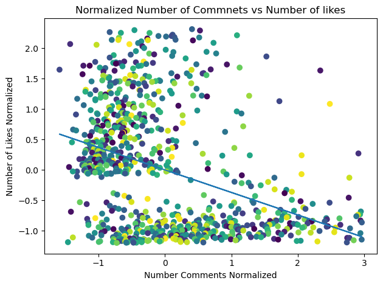

```python
avg_likes = df["likes"].mean()
std_likes = df["likes"].std()

avg_comments = df["comments"].mean()
std_comments = df["comments"].std()


df["likes_normalize"] = (df["likes"] - avg_likes)/std_likes
df["comments_normalize"] = (df["comments"] - avg_comments)/std_comments

#Now we plot the normalize values

plt.rcParams.update({'figure.autolayout': True})
fig, ax = plt.subplots()
ax.scatter(df["comments_normalize"], df["likes_normalize"], c=np.random.randint(0, 100, 849))
#adding linear regression
m, b = np.polyfit(df["comments_normalize"], df["likes_normalize"] , 1)
plt.plot(df["comments_normalize"], m*df["comments_normalize"]+b)

plt.xlabel('Number Comments Normalized')
plt.ylabel('Number of Likes Normalized')
plt.title("Normalized Number of Commnets vs Number of likes")
```

The normalization did not help at all. Ath this point we could conclude that the number of likes and comments is independent. However, we do not know if this claim is statistically "real". We will explain more in the section of hypothesis testing about the statiscally "real."

# Exploration 3 (WARNING - CONTAINS CURSE WORDS AND OFFENSIVE LANGUAGE):

Another guess we can make without seeing the data is that posts with a verdict "Asshole" will result in more anger and curse words in the comments. This step reflects that data analysis is not a straight path. If you think about it we return to the cleaning section because we got a new inquery. This will happen a lot in your projects.

We start by adding some common curse words from wikipedia into a list. We did not add all the curse words since some are ridiculous, and others are straight up racist and not suitable for this project

https://en.wiktionary.org/wiki/Category:English_swear_words

```python
curseWordArray = ["bitch", "pussy", "fuck", "damn", "shit", "wtf", "mf", "dick", "bastard",
                  "fucking", "fuckin", "fkn", "bullshit",
                   "cocksucker","cunt", "damn", "dickhead", "dyke",
                  "goddamn", "motherfucker", "prick", "slut", "twat"]


curseWordArray = [name.upper() for name in curseWordArray] # Turns everything CAPS to not disguish between idiot, and IdiOt

def count_cursing(my_str):

    #This is for the cases in which there is a problem
    if type(my_str) != str:
        #print(str(my_str))
        return -1

    words_list = my_str.split()
    words_list = [name.upper() for name in words_list]
    size = len(words_list)
    total = 0
    for i in range(0,size):
        if words_list[i] in curseWordArray:
            total+=1

    return total

#Creating new columns storing the number of cursing words
df['curse_numb_comment1'] = df["user_comment1"].apply(lambda x: count_cursing(x))
df['curse_numb_comment2'] = df["user_comment2"].apply(lambda x: count_cursing(x))
df['curse_numb_comment3'] = df["user_comment3"].apply(lambda x: count_cursing(x))
df['curse_numb_comment4'] = df["user_comment4"].apply(lambda x: count_cursing(x))
df['curse_numb_comment5'] = df["user_comment5"].apply(lambda x: count_cursing(x))
df['curse_numb_comment6'] = df["user_comment6"].apply(lambda x: count_cursing(x))
df['curse_numb_comment7'] = df["user_comment7"].apply(lambda x: count_cursing(x))
df['curse_numb_comment8'] = df["user_comment8"].apply(lambda x: count_cursing(x))
df['curse_numb_comment9'] = df["user_comment9"].apply(lambda x: count_cursing(x))
df['curse_numb_comment10'] = df["user_comment10"].apply(lambda x: count_cursing(x))
df['curse_numb_story'] = df["story"].apply(lambda x: count_cursing(x))
```

```python
#Checking for the wrong strings.
#df[df['curse_numb_comment3'] < 0]  #After checking we notice that the same rows are the problematics it seems
                                    #those posts did not get enough comments. So, they are labeled with NaN for commnets after 3
df[df['curse_numb_comment4'] < 0]
```

|  | title | author | likes | comments | story | timestamp | verdict | user_comment1 | user_comment2 | user_comment3 | ... | curse_numb_comment2 | curse_numb_comment3 | curse_numb_comment4 | curse_numb_comment5 | curse_numb_comment6 | curse_numb_comment7 | curse_numb_comment8 | curse_numb_comment9 | curse_numb_comment10 | curse_numb_story |
| --- | --- | --- | --- | --- | --- | --- | --- | --- | --- | --- | --- | --- | --- | --- | --- | --- | --- | --- | --- | --- | --- |

0 rows × 31 columns

Now we repeat copy-paste the code above but we changed the return for problematic data since we know they are just NaN results they will get a NaN for the number of cursing words. Thus, if we make a computation those values will be ignored (if we adssign zero they would be take into account in the calculation)

```python
def count_cursing(my_str):

    #This is for the cases in which there is a problem
    if type(my_str) != str:
        #print(str(my_str))
        return np.NaN

    words_list = my_str.split()
    words_list = [name.upper() for name in words_list]
    size = len(words_list)
    total = 0
    for i in range(0,size):
        if words_list[i] in curseWordArray:
            total+=1

    return total

#Creating new columns storing the number of cursing words
df['curse_numb_comment1'] = df["user_comment1"].apply(lambda x: count_cursing(x))
df['curse_numb_comment2'] = df["user_comment2"].apply(lambda x: count_cursing(x))
df['curse_numb_comment3'] = df["user_comment3"].apply(lambda x: count_cursing(x))
df['curse_numb_comment4'] = df["user_comment4"].apply(lambda x: count_cursing(x))
df['curse_numb_comment5'] = df["user_comment5"].apply(lambda x: count_cursing(x))
df['curse_numb_comment6'] = df["user_comment6"].apply(lambda x: count_cursing(x))
df['curse_numb_comment7'] = df["user_comment7"].apply(lambda x: count_cursing(x))
df['curse_numb_comment8'] = df["user_comment8"].apply(lambda x: count_cursing(x))
df['curse_numb_comment9'] = df["user_comment9"].apply(lambda x: count_cursing(x))
df['curse_numb_comment10'] = df["user_comment10"].apply(lambda x: count_cursing(x))
df['curse_numb_story'] = df["story"].apply(lambda x: count_cursing(x))
```

We are going to explore the relationship between the number of cursing words and verdict. We are expecitgn that verdicts in whihc there are assholles have the most number of insults.

```python
 total_curse_words_row = df[['curse_numb_comment1', 'curse_numb_comment2', 'curse_numb_comment3', 'curse_numb_comment4',
   'curse_numb_comment5', 'curse_numb_comment6', 'curse_numb_comment7', 'curse_numb_comment8',
   'curse_numb_comment9', 'curse_numb_comment10']].sum(axis = 1)

mean_curse_words_row = df[['curse_numb_comment1', 'curse_numb_comment2', 'curse_numb_comment3', 'curse_numb_comment4',
   'curse_numb_comment5', 'curse_numb_comment6', 'curse_numb_comment7', 'curse_numb_comment8',
   'curse_numb_comment9', 'curse_numb_comment10']].mean(axis = 1)
```

```
[Text(0.5, 0, 'Total Insults'),
```

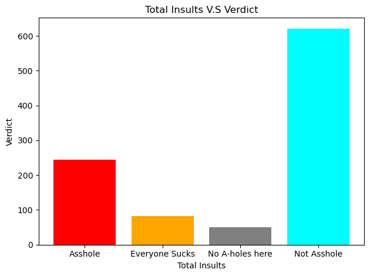

```python
total_curse_word_by_verdict = df.groupby(['verdict'])['curse_numb_comment1', 'curse_numb_comment2', 'curse_numb_comment3', 'curse_numb_comment4',
   'curse_numb_comment5', 'curse_numb_comment6', 'curse_numb_comment7', 'curse_numb_comment8',
   'curse_numb_comment9', 'curse_numb_comment10'].sum() #return data frame
auxiliar = total_curse_word_by_verdict.sum(axis=1)
#total_curse_word_by_verdict.mean(axis=1)
fig, ax = plt.subplots()
ax.bar(total_curse_word_by_verdict.index, auxiliar, color = colors)

ax.set( xlabel='Total Insults', ylabel='Verdict',
      title='Total Insults V.S Verdict')
```

We notice this plot isn't insightful because is uses totals and not averages. A verdict with more observations will have more cursing words in total. So, we change our strategy. We will look at means.

```
[Text(0.5, 0, 'Avg Insults'),
```

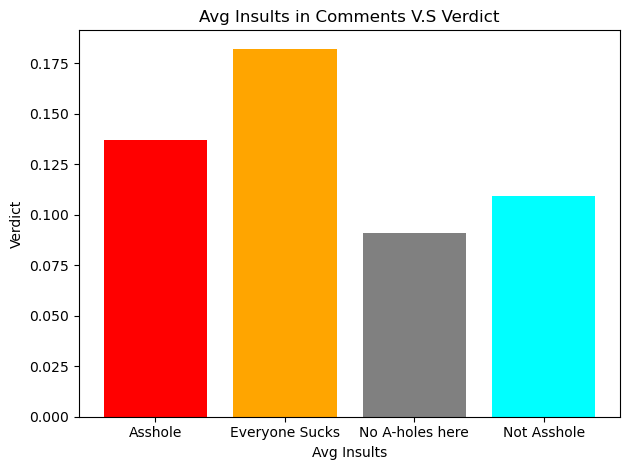

```python
mean_curse_word_by_verdict = df.groupby(['verdict'])['curse_numb_comment1', 'curse_numb_comment2', 'curse_numb_comment3', 'curse_numb_comment4',
   'curse_numb_comment5', 'curse_numb_comment6', 'curse_numb_comment7', 'curse_numb_comment8',
   'curse_numb_comment9', 'curse_numb_comment10'].mean() #return data frame. Row:verdicts columns:curse_commnet1, curse_commnet2...
auxiliar = mean_curse_word_by_verdict.mean(axis=1)


#total_curse_word_by_verdict.mean(axis=1)
fig, ax = plt.subplots()
ax.bar(mean_curse_word_by_verdict.index, auxiliar, color = colors)

ax.set( xlabel='Avg Insults', ylabel='Verdict',
      title='Avg Insults in Comments V.S Verdict')
```

Results: Posts with unfavorable verdicts stir up more rage

Note: Our dataset includes the top 10 comments per post, limiting our data significantly and introducing variables like Reddit's algorithm for filtering out the comments section, which makes our results less reliable. Even then we still see a predictible outcome

We analyzed the number of curse words in the comments. Now lets look at the number of curse words in the POSTS

```
[Text(0.5, 0, 'Avg Insults Story'),
```

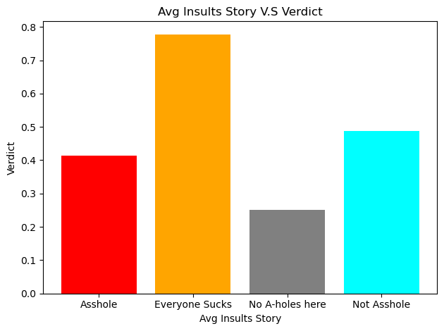

```python
mean_curse_word_by_verdict = df.groupby(['verdict'])['curse_numb_story'].mean() #return data frame. Row:verdicts columns:curse_commnet1, curse_commnet2...

fig, ax = plt.subplots()
ax.bar(mean_curse_word_by_verdict.index,mean_curse_word_by_verdict , color = colors)

ax.set( xlabel='Avg Insults Story', ylabel='Verdict',
      title='Avg Insults Story V.S Verdict')
```

The plot above counts the number of curse words in the POSTS, not the comments. We have the whole story so this analysis is more accurate than the comments section analysis.

We see that cursing is doubled in posts where everyone sucks and halved when there are no assholes, which aligns with our predictions. What does not align with our predictions is the lack of variance in cursing between posts with the other two verdicts

# Exploration 3: Throwaway Accounts

Throwaway accounts are Reddit accounts that are made for one post and are never used afterwards. This preserves the OP's privacy by not tying their post to their main account. We want to see if Assholes are more likely to use throwaway accounts for their post

```python
#Fucntion to determine if an account is a throwawat account
def is_author_throwaway(my_str):
    my_str1 = my_str.upper()
    if my_str == None:
        return False
    elif my_str.find("throwaway") >= 0: #find returns the index of the string we look, retunr -1 if not found
        return True
    else:
        return False

df["is_throwaway"] = df["author"].apply(lambda x : is_author_throwaway(x))
```

```python
#counting the number of throwaways
total_throwaway = df["is_throwaway"].sum()
#counting the number of trowwayas that are Assholes or everyone sucks verdicts
assholes_throwaway = ((df['is_throwaway'] == True) & (df["verdict"].isin(["Asshole", "Everyone Sucks" ]))).sum()

proportion_assholes_throwaway = assholes_throwaway/float(total_throwaway)

#Counting non-throwaways that are not updates

total_no_tr = ((df['is_throwaway'] == False) & (df["verdict"].isin(["No A-holes here", "Not Asshole","Asshole", "Everyone Sucks" ]))).sum()
assholes_no_throwaway = ((df['is_throwaway'] == False) & (df["verdict"].isin(["Asshole", "Everyone Sucks" ]))).sum()

proporiton_assholes_no_throwaway = float(assholes_no_throwaway)/ total_no_tr

print("Proportion of Assholes in throwaway: ")
print(proportion_assholes_throwaway)
print("proportion of Assholes in non-throwaway: ")
print(proporiton_assholes_no_throwaway)
```

```
Proportion of Assholes in throwaway:
0.2711864406779661
proportion of Assholes in non-throwaway:
0.26329113924050634
```

We can see that throwaway accounts are used by both assholes and non assholes alike. Howver, it is this enogh to conclude that there is no a difference between these proportions. In general, for all of our previous claims, can we say that we have enough data says our claims were legitime? This is when hypothesis testing enter in scene.

# Hypothesis Testing

Hypothesis testing help us see if the data that we collect is enough to determine that our result is statistically significant, in other words, that we can be sure about our claim

First, we will test if the averge number of likes per verdict is significally different. To do so we have to find the right type of test. We want to prove if the data for likes from Assholes and Non-Assholes is the same. Thus, we need a test to compare whether the distributions from both populations is the same. We do not have any prior information about the distribution of the populations. Thus, we need a non-parametric test. After reading the infomration from the links below, we decided to use Mann-Whitney U test.

Always remember to set your p-value before doing the testing. If you set it after your hypothesis testing you can introduce bias to your reserach by changing your p-value in such a way that you reject or accept the alternative hypotesis testing at your convenience. We will follow the standard p-value of 0.05. You can read more in the last link below

Interpretation for the testing:

H0: the distributions of both samples are equal.  
H1: the distributions of both samples are not equal.

Test with comparing more than two samples https://en.wikipedia.org/wiki/Kruskal%E2%80%93Wallis_one-way_analysis_of_variance

Comparing one sample, non parametric https://en.wikipedia.org/wiki/Mann%E2%80%93Whitney_U_test#Assumptions_and_formal_statement_of_hypotheses

General guide for using hypothesis testing in Python https://machinelearningmastery.com/statistical-hypothesis-tests-in-python-cheat-sheet/

Significance level https://statisticsbyjim.com/hypothesis-testing/significance-levels/

```python
# Example of the Mann-Whitney U Test
from scipy.stats import mannwhitneyu

#Notice each argument in the function below are just data sets of likes for the different verdicts
stat, p = mannwhitneyu(df[df["verdict"]=="Asshole"]["likes"], df[df["verdict"]=="Not Asshole"]["likes"])
print('stat=%.3f, p=%.3f' % (stat, p))
if p > 0.05:
 print('Probably the same distribution')
else:
 print('Probably different distributions')
```

```
stat=49058.000, p=0.459
Probably the same distribution
```

This result lines up with our previous interpretation of the plots.

```python
# Example of the Mann-Whitney U Test
from scipy.stats import mannwhitneyu

stat, p = mannwhitneyu(df[df["verdict"]=="Everyone Sucks"]["likes"], df[df["verdict"]=="No A-holes here"]["likes"])
print('stat=%.3f, p=%.3f' % (stat, p))
if p > 0.05:
 print('Probably the same distribution')
else:
 print('Probably different distributions')
```

```
stat=1260.500, p=1.000
Probably the same distribution
```

This result matches our result from the plot. Now we will verify whether the population of Assholes, Everyone Sukcs, No A-Holes here, and No A-holes here have the same distribution.

Remember that our previous test works only for two samples. So, what do we have to do first?

We have to find a suitable hypothesis test. After reading the resources above, we found Kruskal-Wallis H test

```python
# Example of the Kruskal-Wallis H Test
from scipy.stats import kruskal

#Notice each argument in the function below are just data sets of likes for the different verdicts
stat, p = kruskal(df[df["verdict"]=="Asshole"]["likes"], df[df["verdict"]=="Not Asshole"]["likes"],
                 df[df["verdict"]=="Everyone Sucks"]["likes"], df[df["verdict"]=="No A-holes here"]["likes"])
print('stat=%.3f, p=%.3f' % (stat, p))
if p > 0.05:
 print('Probably the same distribution')
else:
 print('Probably different distributions')
```

```
stat=0.734, p=0.865
Probably the same distribution
```

# Reason for using the plot analysis and the hypothesis testing

Although we cannot claim anything using only plots; we noticed that the plots were very useful to get intuition behind the problem. Turns out intuition can be correct, like in our case.

# More Hypothesis Testing

We will look at the number of curse words in the first 10 comments for each observation. We recognize that in some way this introduces some inaccuracy in what we are looking to analyze, since Reddit sorts the comments in such a way that the comments with more upvotes are visible. Thus, we will analyze the total number of curse words in the top commnents. Since we are doing the same for all the observations, there won't be bias to analyze, as long as our conclusions are bounded to the top 10 commnents.

First, we calculate the mean number of curse words for each verdict

```python
#df.columns[20:30] is an array containing all the columns with cursing numbers in the data frame
#we use the option skipna = True, so we do not get NaN for the storeis with less than 10 comments

df["mean_cursing_comments"] = df[df.columns[20:30]].mean(axis = 1 , skipna = True)

# Example of the Kruskal-Wallis H Test
from scipy.stats import kruskal

#Notice each argument in the function below are just data sets of likes for the different verdicts
stat, p = kruskal(df[df["verdict"]=="Asshole"]["mean_cursing_comments"],
                  df[df["verdict"]=="Not Asshole"]["mean_cursing_comments"],
                 df[df["verdict"]=="Everyone Sucks"]["mean_cursing_comments"],
                  df[df["verdict"]=="No A-holes here"]["mean_cursing_comments"])
print('stat=%.3f, p=%.3f' % (stat, p))
if p > 0.05:
 print('Probably the same distribution')
else:
 print('Probably different distributions')
```

```
stat=12.236, p=0.007
Probably different distributions
```

We got carried away with the previous result of all of our samples having the same distribution. As we see above, this is not the case with the distribution of the mean number of curse words in the top 10 comments. So, we will try to compare each category with its contrapositive. We will use our old friend to compare two samples, the Mann-Whitney U Test.

```python
# Example of the Mann-Whitney U Test
from scipy.stats import mannwhitneyu

#Notice each argument in the function below are just data sets of likes for the different verdicts
stat, p = mannwhitneyu(df[df["verdict"]=="Asshole"]["mean_cursing_comments"],
                       df[df["verdict"]=="Not Asshole"]["mean_cursing_comments"])
print('stat=%.3f, p=%.3f' % (stat, p))
if p > 0.05:
 print('Probably the same distribution')
else:
 print('Probably different distributions')
```

```
stat=54638.500, p=0.119
Probably the same distribution
```

It is interesting that assholes and non-assholes have a high probability of sharing the same distribution of of curse words. Redditors seem indiferent to a story written by an asshole or a non ass-hole, at least for the top 10 comments.

Now, we look at the everyone sucks and No A-holes here verdicts

```python
# Example of the Mann-Whitney U Test
from scipy.stats import mannwhitneyu

#Notice each argument in the function below are just data sets of likes for the different verdicts
stat, p = mannwhitneyu(df[df["verdict"]=="Everyone Sucks"]["mean_cursing_comments"],
                       df[df["verdict"]=="No A-holes here"]["mean_cursing_comments"])
print('stat=%.3f, p=%.3f' % (stat, p))
if p > 0.01:
 print('Probably the same distribution')
else:
 print('Probably different distributions')
```

```
stat=1663.500, p=0.004
Probably different distributions
```

As we can see the distribution of the averages of cursing words is different for Everyone sucks and No A holes here. Remembering the plot of average curse words for No Assholes here and everyone sucks, we can assert that the distribution of everyone sucks has a higher probailbity of getting curse words than the distribution of No a-holes here. Thus, we could say that redditors show more anger towards stories in which all the protagonists were "bad guys". We will verify this by comparing the distribution for the assholes, not asshole, and no assholes here.

```python
# Example of the Kruskal-Wallis H Test
from scipy.stats import kruskal

#Notice each argument in the function below are just data sets of likes for the different verdicts
stat, p = kruskal(df[df["verdict"]=="Asshole"]["mean_cursing_comments"],
                  df[df["verdict"]=="Not Asshole"]["mean_cursing_comments"],
                  df[df["verdict"]=="No A-holes here"]["mean_cursing_comments"])
print('stat=%.3f, p=%.3f' % (stat, p))
if p > 0.05:
 print('Probably the same distribution')
else:
 print('Probably different distributions')
```

```
stat=3.665, p=0.160
Probably the same distribution
```

We can see that all the verdicts have the same distribution, omitting the everyone sucks verdict. Thus, our previous assertion is very likely to be correct. This is the perspective of the commenters. For completeness, we will look at the side of the posters of the stories.

We will test if the distribution for the number of curse words in the story is different or not.

```python
# Example of the Kruskal-Wallis H Test
from scipy.stats import kruskal

#Notice each argument in the function below are just data sets of likes for the different verdicts
stat, p = kruskal(df[df["verdict"]=="Asshole"]["curse_numb_story"],
                  df[df["verdict"]=="Not Asshole"]["curse_numb_story"],
                 df[df["verdict"]=="Everyone Sucks"]["curse_numb_story"],
                  df[df["verdict"]=="No A-holes here"]["curse_numb_story"])
print('stat=%.3f, p=%.3f' % (stat, p))
if p > 0.01:
 print('Probably the same distribution')
else:
 print('Probably different distributions')
```

```
stat=12.184, p=0.007
Probably different distributions
```

The distirubtions are completly different. We will test for each category and its oppostite like we did before

```python
#Notice each argument in the function below are just data sets of likes for the different verdicts
stat, p = mannwhitneyu(df[df["verdict"]=="Everyone Sucks"]["curse_numb_story"],
                       df[df["verdict"]=="No A-holes here"]["curse_numb_story"])
print('stat=%.3f, p=%.3f' % (stat, p))
if p > 0.05:
 print('Probably the same distribution')
else:
 print('Probably different distributions')
```

```
stat=1617.500, p=0.002
Probably different distributions
```

```python
stat, p = mannwhitneyu(df[df["verdict"]=="Asshole"]["curse_numb_story"],
                       df[df["verdict"]=="Not Asshole"]["curse_numb_story"])
print('stat=%.3f, p=%.3f' % (stat, p))
if p > 0.05:
 print('Probably the same distribution')
else:
 print('Probably different distributions')
```

```
stat=48169.000, p=0.164
Probably the same distribution
```

```python
#Notice each argument in the function below are just data sets of likes for the different verdicts
stat, p = kruskal(df[df["verdict"]=="Asshole"]["curse_numb_story"],
                  df[df["verdict"]=="Not Asshole"]["curse_numb_story"],
                  df[df["verdict"]=="No A-holes here"]["curse_numb_story"])
print('stat=%.3f, p=%.3f' % (stat, p))
if p > 0.05:
 print('Probably the same distribution')
else:
 print('Probably different distributions')
```

```
stat=6.574, p=0.037
Probably different distributions
```

# Another type of Hypothesis Testing

You may have noticed that we have skipped the last topic that came up during data exploration. We skipped the question regarding the relationship between throwaway accounts and the number of people in each verdict because for that type of test we need a special test that takes into account the categorical variables, in this case, thowaway account or not. We will use Pearson's Chi Square Test.

H0: States that there is no relation between the variables.  
H1: State that there is a significant relation between the two.

You can read more about it here: https://www.geeksforgeeks.org/python-pearsons-chi-square-test/

```python
from scipy.stats import chi2_contingency


#Data for throwaway accounts
#counting how many thowayas in each type of verdict
away_sucks = df[df["verdict"]=="Everyone Sucks"]["is_throwaway"].sum()
away_no_assholes = df[df["verdict"]=="No A-holes here"]["is_throwaway"].sum()
away_not_asshole = df[df["verdict"]=="Not Asshole"]["is_throwaway"].sum()
away_asshole = df[df["verdict"]=="Asshole"]["is_throwaway"].sum()

#data for non-trowaway accounts
#We substract the total number of rows in a category and the number of towaway acounts to find the non-trowawaya accounts in
#each verdict
not_away_sucks = df[df["verdict"]=="Everyone Sucks"].shape[0] - away_sucks
not_away_no_assholes = df[df["verdict"]=="No A-holes here"].shape[0] - away_no_assholes
not_away_not_asshole = df[df["verdict"]=="Not Asshole"].shape[0] - away_not_asshole
not_away_asshole = df[df["verdict"]=="Asshole"].shape[0] - away_asshole

# defining the table
data = [[away_sucks, away_no_assholes, away_not_asshole, away_asshole ],
        [not_away_sucks, not_away_no_assholes, not_away_not_asshole, not_away_asshole]]
stat, p, dof, expected = chi2_contingency(data)

# interpret p-value
alpha = 0.05
print("p value is " + str(p))
if p <= alpha:
    print('Dependent (reject H0)')
else:
    print('Independent (H0 holds true)')
```

```
p value is 0.9619571826853408
Independent (H0 holds true)
```

We fail to reject the null hypothesis. Thus, we assume that there is no relationship between throwaway accounts and verdict. This is very surprising and we believe that further reserach should consider what causes people to use a throwaway account.

# Linear Regression

At this point, we got some insight between the relationship of the verdict and the other variables. Now we are past the point of creating a linear regression. So, if a user wants to publish a story, they can use these results to optimize their post, if they so choose.

The user controls the number of curse words in their story. For this reason, we treat the number of curse words as a continuous variable. A naive appraoch would be to make a linear regression only for curse words.

```python
# We define a linear function that will become hangly later
def my_line_func(m,b, x):
    return m*x+b
```

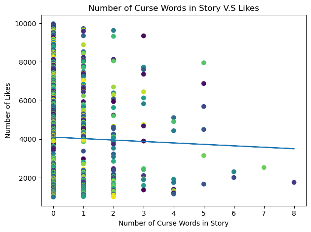

```python
plt.rcParams.update({'figure.autolayout': True})
fig, ax = plt.subplots()
ax.scatter(df["curse_numb_story"], df["likes"], c=np.random.randint(0, 1704, 849))
#adding linear regression
m, b = np.polyfit(df["curse_numb_story"], df["likes"] , 1)
plt.plot(df["curse_numb_story"], m*df["curse_numb_story"]+b)

plt.xlabel('Number of Curse Words in Story')
plt.ylabel('Number of Likes')
plt.title("Number of Curse Words in Story V.S Likes")
```

This does not look like a good regression at all. We notice we have too many points for zero. Thus, the error would be too big. Another way to know if the regression is a good one is by looking at the distribution of the results. That is, the subraction of predicted value and the real value.

```
[Text(0.5, 1.0, 'Violin Plot For Error')]
```

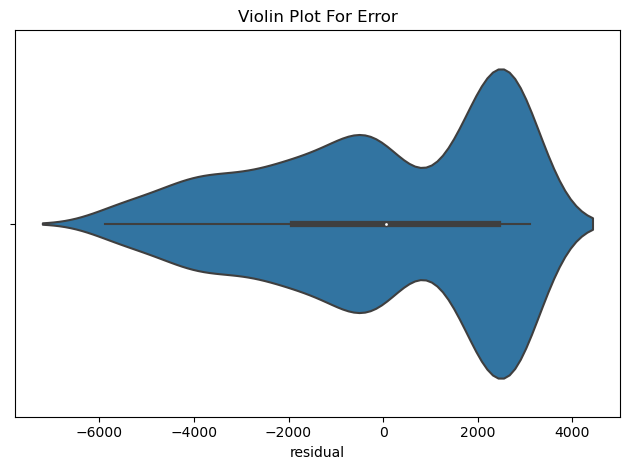

```python
df["residual"] = df.apply(lambda k: my_line_func(m, b, k["curse_numb_story"])- k['likes'] , axis=1)

sns.violinplot(data=df, x="residual").set(title='Violin Plot For Error')
```

If it is a good regression, we should get a normal distribution with mean zero. As we can see from the plot above, the distribtuon is not symmetric, making it is a terrible linear regression.

We forgot to consider another important factor that the user controls. Can you guess the factor?.... It is the verdict.

We will try to fix it.

First, we compute the linear regression for different verdicts

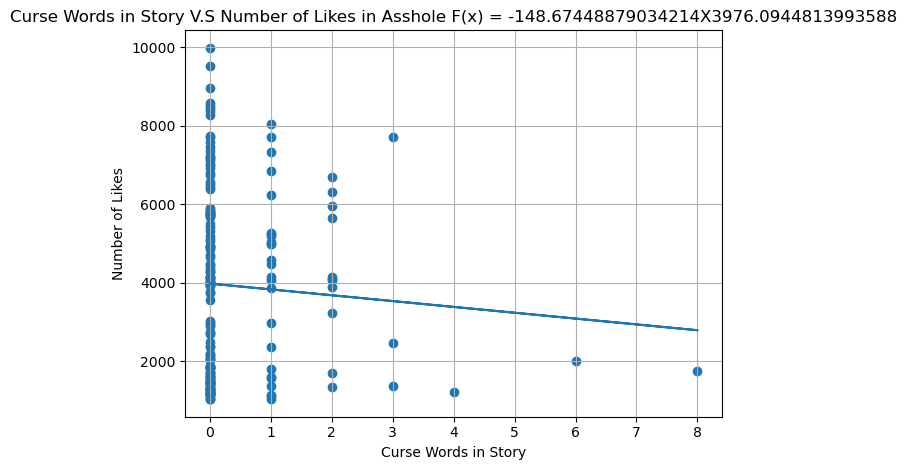

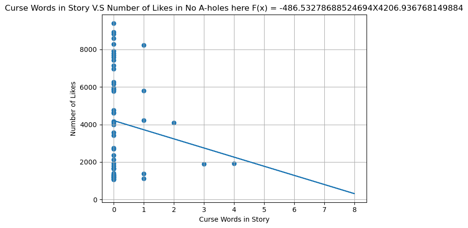

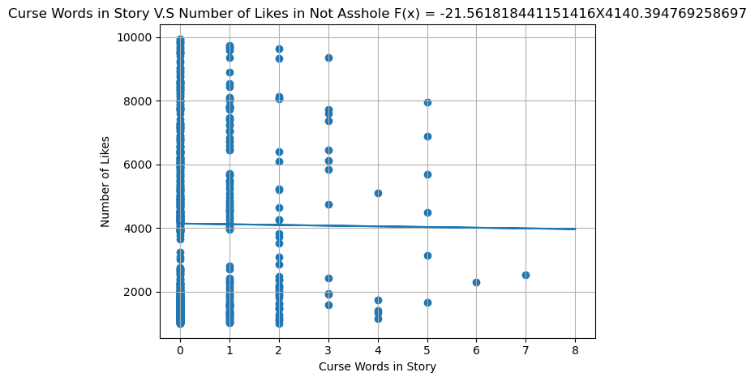

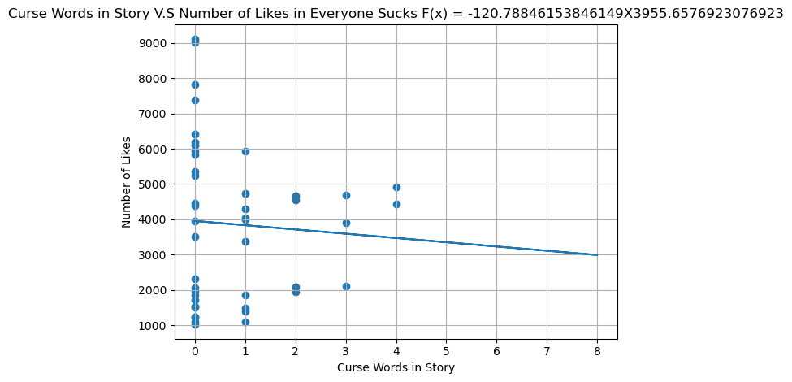

```python
for i in ['Asshole', 'No A-holes here', 'Not Asshole', 'Everyone Sucks']:
    fig, ax = plt.subplots()
    ax.scatter(df[df["verdict"] == i]["curse_numb_story"], df[df["verdict"] == i]["likes"] )
    #adding linear regression
    m, b = np.polyfit(df[df["verdict"] == i]["curse_numb_story"], df[df["verdict"] == i]["likes"], 1)
    plt.plot(df["curse_numb_story"], m*df["curse_numb_story"]+b)

    plt.xlabel('Curse Words in Story')
    plt.ylabel('Number of Likes')
    plt.title('Curse Words in Story V.S Number of Likes in ' + str(i)+ " F(x) = "+str(m)+"X"+str(b))
    #plt.text(1.5 , 200, r'$\mu=63397940,\ \sigma=3.8203620 $', fontsize = 15)
    plt.grid(True)

plt.show()
```

The linear regression for the different verdicts have a different slope; the regressions are not parallel. Thus, a change in verdicts produces different effects in the number of likes. So we, will include it in our model.

```python
from statsmodels.formula.api import ols

mod = ols(formula="likes ~ curse_numb_story * verdict ", data=df)
#mod = ols(formula="lifeExp ~ year * continent ", data=df) #To eliminate the independent variables
res = mod.fit()
res.params
```

```
Intercept                                      3976.094481
verdict[T.Everyone Sucks]                       -20.436789
verdict[T.No A-holes here]                      230.842287
verdict[T.Not Asshole]                          164.300288
curse_numb_story                               -148.674489
curse_numb_story:verdict[T.Everyone Sucks]       27.886027
curse_numb_story:verdict[T.No A-holes here]    -337.858298
curse_numb_story:verdict[T.Not Asshole]         127.112670
dtype: float64
```

```python
#Extracting the parameters
intercept, Everyone_Sucks_dummy, No_A_holes_here_dummy, Not_Asshole_dummy, curse_numb_story_coef, curse_every_sucks, curse_No_a_holes, curse_not_asshole= res.params
```

Before continuing, we decided to see if the parameters are significantly different than zero. Remember that P > \t| tells us the P-value. If the P-value is less than alpha (0.05) then we reject the null hypothesis. That a parameter is zero. So almost all parameters are not significally different than zero. Thus, this would be a terrible regression. We cannot continue with our regression because it would be a terrible fit :( Howver, we expect that at least you got an idea of how to do a linear regression.

```python
print(res.summary())
```

```
                            OLS Regression Results
==============================================================================
Dep. Variable:                  likes   R-squared:                       0.004
Model:                            OLS   Adj. R-squared:                 -0.005
Method:                 Least Squares   F-statistic:                    0.4502
Date:                Fri, 16 Dec 2022   Prob (F-statistic):              0.870
Time:                        21:55:06   Log-Likelihood:                -7863.3
No. Observations:                 849   AIC:                         1.574e+04
Df Residuals:                     841   BIC:                         1.578e+04
Df Model:                           7
Covariance Type:            nonrobust
===============================================================================================================
                                                  coef    std err          t      P>|t|      [0.025      0.975]
---------------------------------------------------------------------------------------------------------------
Intercept                                    3976.0945    206.811     19.226      0.000    3570.168    4382.021
verdict[T.Everyone Sucks]                     -20.4368    506.898     -0.040      0.968   -1015.370     974.496
verdict[T.No A-holes here]                    230.8423    416.151      0.555      0.579    -585.974    1047.658
verdict[T.Not Asshole]                        164.3003    239.057      0.687      0.492    -304.918     633.519
curse_numb_story                             -148.6745    190.035     -0.782      0.434    -521.672     224.323
curse_numb_story:verdict[T.Everyone Sucks]     27.8860    386.652      0.072      0.943    -731.030     786.802
curse_numb_story:verdict[T.No A-holes here]  -337.8583    500.906     -0.674      0.500   -1321.032     645.315
curse_numb_story:verdict[T.Not Asshole]       127.1127    219.538      0.579      0.563    -303.794     558.019
==============================================================================
Omnibus:                      173.021   Durbin-Watson:                   0.023
Prob(Omnibus):                  0.000   Jarque-Bera (JB):               66.481
Skew:                           0.493   Prob(JB):                     3.66e-15
Kurtosis:                       2.047   Cond. No.                         11.2
==============================================================================

Notes:
[1] Standard Errors assume that the covariance matrix of the errors is correctly specified.
```

# Conclusion

After our deep analysis of the subreddit AITA we have found that some of our predictions were accurate, others were not, and then we have all the gray area in between. One must always look at context in these scenarios as the context can explain the results you get. Numbers aren't the only thing to consider.

This concludes our tutorial! I hope everyone reading was able to gain inspiration from our work and goes on to create amazing things.